# Machine Learning with caret

# 1 Learn ML with caret

from: https://www.machinelearningplus.com/machine-learning/caret-package/

## 1.1 Requirements & setteings

```r
options(scipen = 999)
```

### 1.1.1 installing packages

```r
# install.packages(c("skimr", "RANN"))
```

```
There were 21 warnings (use warnings() to see them)
```

```r
install.packages("caretEnsemble")
```

### 1.1.2 install libraries

```r
library(caretEnsemble)
```

### 1.1.3 Importing Data

```r
orange <- read.csv('https://raw.githubusercontent.com/selva86/datasets/master/orange_juice_withmissing.csv')
head(orange)
```

|  | Purchase | WeekofPurchase | StoreID | PriceCH | PriceMM | DiscCH | DiscMM | SpecialCH | SpecialMM | LoyalCH | SalePriceMM | SalePriceCH | PriceDiff | Store7 | PctDiscMM | PctDiscCH | ListPriceDiff | STORE |
| --- | --- | --- | --- | --- | --- | --- | --- | --- | --- | --- | --- | --- | --- | --- | --- | --- | --- | --- |
| 1 | CH | 237 | 1 | 1.75 | 1.99 | 0.00 | 0.0 | 0 | 0 | 0.500000 | 1.99 | 1.75 | 0.24 | No | 0.000000 | 0.000000 | 0.24 | 1 |
| 2 | CH | 239 | 1 | 1.75 | 1.99 | 0.00 | 0.3 | 0 | 1 | 0.600000 | 1.69 | 1.75 | -0.06 | No | 0.150754 | 0.000000 | 0.24 | 1 |
| 3 | CH | 245 | 1 | 1.86 | 2.09 | 0.17 | 0.0 | 0 | 0 | 0.680000 | 2.09 | 1.69 | 0.40 | No | 0.000000 | 0.091398 | 0.23 | 1 |
| 4 | MM | 227 | 1 | 1.69 | 1.69 | 0.00 | 0.0 | 0 | 0 | 0.400000 | 1.69 | 1.69 | 0.00 | No | 0.000000 | 0.000000 | 0.00 | 1 |
| 5 | CH | 228 | 7 | 1.69 | 1.69 | 0.00 | 0.0 | 0 | 0 | 0.956535 | 1.69 | 1.69 | 0.00 | Yes | 0.000000 | 0.000000 | 0.00 | 0 |
| 6 | CH | 230 | 7 | 1.69 | 1.99 | 0.00 | 0.0 | 0 | 1 | 0.965228 | 1.99 | 1.69 | 0.30 | Yes | 0.000000 | 0.000000 | 0.30 | 0 |

```r
str(orange)
```

```
'data.frame':   1070 obs. of  18 variables:
 $ Purchase      : chr  "CH" "CH" "CH" "MM" ...
 $ WeekofPurchase: int  237 239 245 227 228 230 232 234 235 238 ...
 $ StoreID       : int  1 1 1 1 7 7 7 7 7 7 ...
 $ PriceCH       : num  1.75 1.75 1.86 1.69 1.69 1.69 1.69 1.75 1.75 1.75 ...
 $ PriceMM       : num  1.99 1.99 2.09 1.69 1.69 1.99 1.99 1.99 1.99 1.99 ...
 $ DiscCH        : num  0 0 0.17 0 0 0 0 0 0 0 ...
 $ DiscMM        : num  0 0.3 0 0 0 0 0.4 0.4 0.4 0.4 ...
 $ SpecialCH     : int  0 0 0 0 0 0 1 1 0 0 ...
 $ SpecialMM     : int  0 1 0 0 0 1 1 0 0 0 ...
 $ LoyalCH       : num  0.5 0.6 0.68 0.4 0.957 ...
 $ SalePriceMM   : num  1.99 1.69 2.09 1.69 1.69 1.99 1.59 1.59 1.59 1.59 ...
 $ SalePriceCH   : num  1.75 1.75 1.69 1.69 1.69 1.69 1.69 1.75 1.75 1.75 ...
 $ PriceDiff     : num  0.24 -0.06 0.4 0 0 0.3 -0.1 -0.16 -0.16 -0.16 ...
 $ Store7        : chr  "No" "No" "No" "No" ...
 $ PctDiscMM     : num  0 0.151 0 0 0 ...
 $ PctDiscCH     : num  0 0 0.0914 0 0 ...
 $ ListPriceDiff : num  0.24 0.24 0.23 0 0 0.3 0.3 0.24 0.24 0.24 ...
 $ STORE         : int  1 1 1 1 0 0 0 0 0 0 ...
```

```r
skimr::skim(orange)  # skim_to_wide' is deprecated. Use 'skim()' instead.
```

```
-- Data Summary ------------------------
                           Values
Name                       orange
Number of rows             1070
Number of columns          18
_______________________
Column type frequency:
  character                2
  numeric                  16
________________________
Group variables            None
```

[output not shown]

```
-- Variable type: character --------------------------------------------------------------------------------------------------------
# A tibble: 2 x 8
  skim_variable n_missing complete_rate   min   max empty n_unique whitespace
* <chr>             <int>         <dbl> <int> <int> <int>    <int>      <int>
1 Purchase              0             1     2     2     0        2          0
2 Store7                0             1     2     3     0        2          0
```

[output not shown]

```
-- Variable type: numeric ----------------------------------------------------------------------------------------------------------
# A tibble: 16 x 11
   skim_variable  n_missing complete_rate     mean      sd         p0    p25    p50     p75    p100 hist
 * <chr>              <int>         <dbl>    <dbl>   <dbl>      <dbl>  <dbl>  <dbl>   <dbl>   <dbl> <chr>
 1 WeekofPurchase         0         1     254.     15.6    227        240    257    268     278     ▆▅▅▇▇
 2 StoreID                1         0.999   3.96    2.31     1          2      3      7       7     ▇▅▃▁▇
 3 PriceCH                1         0.999   1.87    0.102    1.69       1.79   1.86   1.99    2.09  ▅▂▇▆▁
 4 PriceMM                4         0.996   2.09    0.134    1.69       1.99   2.09   2.18    2.29  ▂▁▃▇▆
 5 DiscCH                 2         0.998   0.0520  0.118    0          0      0      0       0.5   ▇▁▁▁▁
 6 DiscMM                 4         0.996   0.123   0.214    0          0      0      0.23    0.8   ▇▁▂▁▁
 7 SpecialCH              2         0.998   0.147   0.354    0          0      0      0       1     ▇▁▁▁▂
 8 SpecialMM              5         0.995   0.162   0.369    0          0      0      0       1     ▇▁▁▁▂
 9 LoyalCH                5         0.995   0.565   0.308    0.000011   0.32   0.6    0.851   1.00  ▅▃▆▆▇
10 SalePriceMM            5         0.995   1.96    0.253    1.19       1.69   2.09   2.13    2.29  ▁▂▂▂▇
11 SalePriceCH            1         0.999   1.82    0.143    1.39       1.75   1.86   1.89    2.09  ▂▁▇▇▅
12 PriceDiff              1         0.999   0.146   0.272   -0.67       0      0.23   0.32    0.64  ▁▂▃▇▂
13 PctDiscMM              5         0.995   0.0594  0.102    0          0      0      0.113   0.402 ▇▁▂▁▁
14 PctDiscCH              2         0.998   0.0273  0.0623   0          0      0      0       0.253 ▇▁▁▁▁
15 ListPriceDiff          0         1       0.218   0.108    0          0.14   0.24   0.3     0.44  ▂▃▆▇▁
16 STORE                  2         0.998   1.63    1.43     0          0      2      3       4     ▇▃▅▅▃
```

### 1.1.4 changing data type of Y variable

```r
orange$Purchase <- as.factor(orange$Purchase)

skim(orange)
```

```
-- Data Summary ------------------------
                           Values
Name                       orange
Number of rows             1070
Number of columns          18
_______________________
Column type frequency:
  character                1
  factor                   1
  numeric                  16
________________________
Group variables            None
```

[output not shown]

```
-- Variable type: character --------------------------------------------------------------------------------------------------------
# A tibble: 1 x 8
  skim_variable n_missing complete_rate   min   max empty n_unique whitespace
* <chr>             <int>         <dbl> <int> <int> <int>    <int>      <int>
1 Store7                0             1     2     3     0        2          0
```

[output not shown]

```
-- Variable type: factor -----------------------------------------------------------------------------------------------------------
# A tibble: 1 x 6
  skim_variable n_missing complete_rate ordered n_unique top_counts
* <chr>             <int>         <dbl> <lgl>      <int> <chr>
1 Purchase              0             1 FALSE          2 CH: 653, MM: 417
```

[output not shown]

```
-- Variable type: numeric ----------------------------------------------------------------------------------------------------------
# A tibble: 16 x 11
   skim_variable  n_missing complete_rate     mean      sd         p0    p25    p50     p75    p100 hist
 * <chr>              <int>         <dbl>    <dbl>   <dbl>      <dbl>  <dbl>  <dbl>   <dbl>   <dbl> <chr>
 1 WeekofPurchase         0         1     254.     15.6    227        240    257    268     278     ▆▅▅▇▇
 2 StoreID                1         0.999   3.96    2.31     1          2      3      7       7     ▇▅▃▁▇
 3 PriceCH                1         0.999   1.87    0.102    1.69       1.79   1.86   1.99    2.09  ▅▂▇▆▁
 4 PriceMM                4         0.996   2.09    0.134    1.69       1.99   2.09   2.18    2.29  ▂▁▃▇▆
 5 DiscCH                 2         0.998   0.0520  0.118    0          0      0      0       0.5   ▇▁▁▁▁
 6 DiscMM                 4         0.996   0.123   0.214    0          0      0      0.23    0.8   ▇▁▂▁▁
 7 SpecialCH              2         0.998   0.147   0.354    0          0      0      0       1     ▇▁▁▁▂
 8 SpecialMM              5         0.995   0.162   0.369    0          0      0      0       1     ▇▁▁▁▂
 9 LoyalCH                5         0.995   0.565   0.308    0.000011   0.32   0.6    0.851   1.00  ▅▃▆▆▇
10 SalePriceMM            5         0.995   1.96    0.253    1.19       1.69   2.09   2.13    2.29  ▁▂▂▂▇
11 SalePriceCH            1         0.999   1.82    0.143    1.39       1.75   1.86   1.89    2.09  ▂▁▇▇▅
12 PriceDiff              1         0.999   0.146   0.272   -0.67       0      0.23   0.32    0.64  ▁▂▃▇▂
13 PctDiscMM              5         0.995   0.0594  0.102    0          0      0      0.113   0.402 ▇▁▂▁▁
14 PctDiscCH              2         0.998   0.0273  0.0623   0          0      0      0       0.253 ▇▁▁▁▁
15 ListPriceDiff          0         1       0.218   0.108    0          0.14   0.24   0.3     0.44  ▂▃▆▇▁
16 STORE                  2         0.998   1.63    1.43     0          0      2      3       4     ▇▃▅▅▃
```

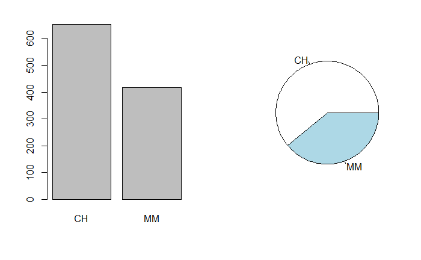

```r
par(mfrow = c(1,2))
barplot(table(orange$Purchase))
pie(table(orange$Purchase))
```

```r
table(orange$Purchase)[1]
```

```
 CH
653
```

## 1.2 Mean values based on Y groups

```r
orange %>% group_by(Purchase) %>% summarise(across(where(is.numeric), mean) )
```

| Purchase | WeekofPurchase | StoreID | PriceCH | PriceMM | DiscCH | DiscMM | SpecialCH | SpecialMM | LoyalCH | SalePriceMM | SalePriceCH | PriceDiff | PctDiscMM | PctDiscCH | ListPriceDiff | STORE |
| --- | --- | --- | --- | --- | --- | --- | --- | --- | --- | --- | --- | --- | --- | --- | --- | --- |
| CH | 255.9418 | NA | 1.869296 | NA | NA | NA | NA | NA | NA | NA | 1.800429 | 0.2061409 | NA | NA | 0.2321286 | NA |
| MM | 251.9376 | 3.230216 | NA | NA | NA | NA | 0.08872902 | NA | NA | NA | NA | NA | NA | 0.01313131 | 0.1958513 | NA |

it will be good to apply this once NA’s are imputed

## 1.3 Data Prep.

### 1.3.1 splitting data

```r
set.seed(100)

trainRowNumb <- createDataPartition(orange$Purchase, p=0.8, list = FALSE)
```

#### 1.3.1.1 creating train & test

```r
trainData <- orange[trainRowNumb, ]
testData <- orange[-trainRowNumb, ]
```

#### 1.3.1.2 creating x, y from train data

```r
x = subset(trainData, select = -c(Purchase))
y = subset(trainData, select = c(Purchase))
```

### 1.3.2 Impute Missing values

To predict the missing values with k-Nearest Neighbors using preProcess(): set method=knnImpute

#### 1.3.2.1 creating knn model on training data

```r
preProcess_missingdata_model <- preProcess(trainData, method = "knnImpute")

preProcess_missingdata_model
```

```
Created from 827 samples and 18 variables

Pre-processing:
  - centered (16)
  - ignored (2)
  - 5 nearest neighbor imputation (16)
  - scaled (16)
```

#### 1.3.2.2 predicting missing values

Let’s now use this model to predict the missing values in trainData.

this will require library(RANN)

```r
trainData <- predict(preProcess_missingdata_model, newdata = trainData)

anyNA(trainData)
```

```
[1] FALSE
```

### 1.3.3 One hot encoding / dummyVars()

```r
dummies_model <- dummyVars(Purchase ~ . , data = trainData)

trainData_mat <- predict(dummies_model, newdata = trainData)
```

```
variable 'Purchase' is not a factor
```

```r
trainData <- data.frame(trainData_mat)


str(trainData)
```

```
'data.frame':   857 obs. of  18 variables:
 $ WeekofPurchase: num  -1.097 -0.969 -0.586 -1.737 -1.673 ...
 $ StoreID       : num  -1.29 -1.29 -1.29 -1.29 1.29 ...
 $ PriceCH       : num  -1.1422 -1.1422 -0.0592 -1.7329 -1.7329 ...
 $ PriceMM       : num  -0.6795 -0.6795 0.0498 -2.8676 -2.8676 ...
 $ DiscCH        : num  -0.444 -0.444 0.981 -0.444 -0.444 ...
 $ DiscMM        : num  -0.578 0.793 -0.578 -0.578 -0.578 ...
 $ SpecialCH     : num  -0.425 -0.425 -0.425 -0.425 -0.425 ...
 $ SpecialMM     : num  -0.447 2.235 -0.447 -0.447 -0.447 ...
 $ LoyalCH       : num  -0.211 0.116 0.378 -0.539 1.284 ...
 $ SalePriceMM   : num  0.13 -1.037 0.519 -1.037 -1.037 ...
 $ SalePriceCH   : num  -0.432 -0.432 -0.843 -0.843 -0.843 ...
 $ PriceDiff     : num  0.352 -0.744 0.936 -0.525 -0.525 ...
 $ Store7No      : num  1 1 1 1 0 0 0 0 0 0 ...
 $ Store7Yes     : num  0 0 0 0 1 1 1 1 1 1 ...
 $ PctDiscMM     : num  -0.587 0.861 -0.587 -0.587 -0.587 ...
 $ PctDiscCH     : num  -0.44 -0.44 1 -0.44 -0.44 ...
 $ ListPriceDiff : num  0.21 0.21 0.118 -2.012 -2.012 ...
 $ STORE         : num  -0.412 -0.412 -0.412 -0.412 -1.111 ...
```

Seems like using **One hot encoding** from `library dummies` is much easier

### 1.3.4 scaling etc.

```r
preProcess_range_model <- preProcess(trainData, method = "range")

trainData <- predict(preProcess_range_model, newdata = trainData)
```

#### 1.3.4.1 Appending Y variable to train data

```r
trainData$Purchase <- pull(y)
```

#### 1.3.4.2 Apply min max

```r
apply(trainData[, 1:10], 2, FUN=function(x){
  c('min' = min(x),
    'max' = max(x))
})
```

```
    WeekofPurchase StoreID PriceCH PriceMM DiscCH DiscMM SpecialCH SpecialMM LoyalCH SalePriceMM
min              0       0       0       0      0      0         0         0       0           0
max              1       1       1       1      1      1         1         1       1           1
```

## 1.4 Variable Importance

### 1.4.1 Mean values based on Y groups

Applying again after imputing NA values

```r
trainData %>% group_by(Purchase) %>% summarise(across(where(is.numeric), mean) )
```

| Purchase | WeekofPurchase | StoreID | PriceCH | PriceMM | DiscCH | DiscMM | SpecialCH | SpecialMM | LoyalCH | SalePriceMM | SalePriceCH | PriceDiff | Store7No | Store7Yes | PctDiscMM | PctDiscCH | ListPriceDiff | STORE |
| --- | --- | --- | --- | --- | --- | --- | --- | --- | --- | --- | --- | --- | --- | --- | --- | --- | --- | --- |
| CH | 0.5641285 | 0.5777565 | 0.4442639 | 0.6830784 | 0.13912046 | 0.1227533 | 0.19349904 | 0.1166348 | 0.7236333 | 0.7378585 | 0.5830647 | 0.6667932 | 0.5717017 | 0.4282983 | 0.1178437 | 0.14583972 | 0.5275943 | 0.3672084 |
| MM | 0.4830926 | 0.3827345 | 0.4333832 | 0.6122754 | 0.05353293 | 0.2134281 | 0.08982036 | 0.2455090 | 0.3135143 | 0.6333152 | 0.6379812 | 0.5496640 | 0.7844311 | 0.2155689 | 0.2036326 | 0.05530056 | 0.4409363 | 0.4468563 |

```r
head(trainData)
```

|  | WeekofPurchase | StoreID | PriceCH | PriceMM | DiscCH | DiscMM | SpecialCH | SpecialMM | LoyalCH | SalePriceMM | SalePriceCH | PriceDiff | Store7No | Store7Yes | PctDiscMM | PctDiscCH | ListPriceDiff | STORE | Purchase |
| --- | --- | --- | --- | --- | --- | --- | --- | --- | --- | --- | --- | --- | --- | --- | --- | --- | --- | --- | --- |
| 1 | 0.19607843 | 0 | 0.150 | 0.5000000 | 0.00 | 0.000 | 0 | 0 | 0.5000210 | 0.7272727 | 0.5142857 | 0.6946565 | 1 | 0 | 0.0000000 | 0.000000 | 0.5454545 | 0.25 | CH |
| 2 | 0.23529412 | 0 | 0.150 | 0.5000000 | 0.00 | 0.375 | 0 | 1 | 0.6000274 | 0.4545455 | 0.5142857 | 0.4656489 | 1 | 0 | 0.3750006 | 0.000000 | 0.5454545 | 0.25 | CH |
| 3 | 0.35294118 | 0 | 0.425 | 0.6666667 | 0.34 | 0.000 | 0 | 0 | 0.6800325 | 0.8181818 | 0.4285714 | 0.8167939 | 1 | 0 | 0.0000000 | 0.361703 | 0.5227273 | 0.25 | CH |
| 4 | 0.00000000 | 0 | 0.000 | 0.0000000 | 0.00 | 0.000 | 0 | 0 | 0.4000146 | 0.4545455 | 0.4285714 | 0.5114504 | 1 | 0 | 0.0000000 | 0.000000 | 0.0000000 | 0.25 | MM |
| 5 | 0.01960784 | 1 | 0.000 | 0.0000000 | 0.00 | 0.000 | 0 | 0 | 0.9565852 | 0.4545455 | 0.4285714 | 0.5114504 | 0 | 1 | 0.0000000 | 0.000000 | 0.0000000 | 0.00 | CH |
| 6 | 0.05882353 | 1 | 0.000 | 0.5000000 | 0.00 | 0.000 | 0 | 1 | 0.9652788 | 0.7272727 | 0.4285714 | 0.7404580 | 0 | 1 | 0.0000000 | 0.000000 | 0.6818182 | 0.00 | CH |

### 1.4.2 feature plot - boxplot

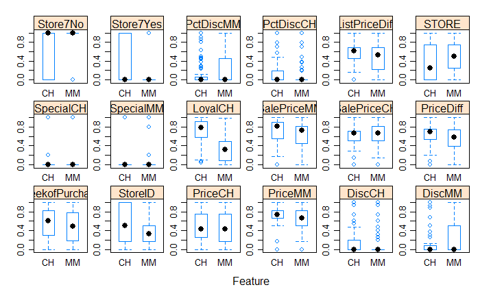

```r
featurePlot(x = trainData[,1:18], y = trainData$Purchase, plot = "box",
            scales = list(x = list(relation = "free"), y = list(relation = "free")))
```

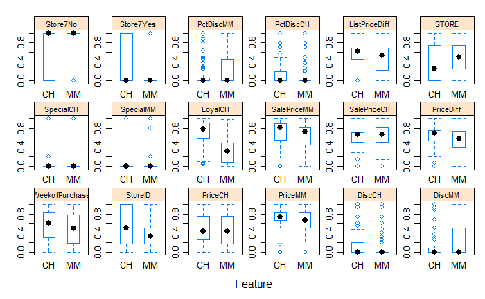

```r
featurePlot(x = trainData[, 1:18],
            y = trainData$Purchase,
            plot = "box",
            strip=strip.custom(par.strip.text=list(cex=.7)),
            scales = list(x = list(relation="free"),
                          y = list(relation="free")))
```

As we can see from the above chart `LoyalCH` variable has non overlapping distribution so that can be a very imp variable as a predictor

### 1.4.3 feature plot - desnity

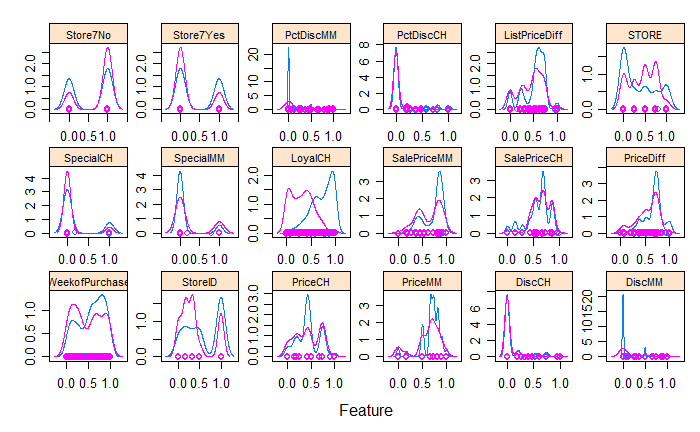

```r
featurePlot(x = trainData[, 1:18],
            y = trainData$Purchase,
            plot = "density",
            strip=strip.custom(par.strip.text=list(cex=.7)),
            scales = list(x = list(relation="free"),
                          y = list(relation="free")))
```

seems like `LoyalCH` is strong predictor and `STORE, WeekofPurchase, StoreID` could also be useful

### 1.4.4 RFE

Recursive Feature Elimination

```r
names(trainData)
```

```
 [1] "WeekofPurchase" "StoreID"        "PriceCH"        "PriceMM"        "DiscCH"         "DiscMM"         "SpecialCH"
 [8] "SpecialMM"      "LoyalCH"        "SalePriceMM"    "SalePriceCH"    "PriceDiff"      "Store7No"       "Store7Yes"
[15] "PctDiscMM"      "PctDiscCH"      "ListPriceDiff"  "STORE"          "Purchase"
```

The `sizes` determines what all model sizes (the number of most important features) the rfe should consider. In above case, it iterates models of size 1 to 5, 10, 15 and 18.

The `rfeControl` parameter on the other hand receives the output of the rfeControl() as values. If you look at the call to rfeControl() we set what type of algorithm and what cross validation method should be used.

In above case, the cross validation method is `repeatedcv` which implements k-Fold cross validation repeated 5 times, which is rigorous enough for our case.

```r
set.seed(100)

options(warn = -1)

subsets <- c(1:5, 10, 15, 18)   # its not clear why they selected only these vars

ctrl <- rfeControl(functions = rfFuncs,
                   method = "repeatedcv",
                   repeats = 5,
                   verbose = F)

lmProfile <- rfe(x = trainData[, 1:18], y = trainData$Purchase,
                 sizes = subsets,
                 rfeControl = ctrl)

lmProfile
```

```
Recursive feature selection

Outer resampling method: Cross-Validated (10 fold, repeated 5 times)

Resampling performance over subset size:
```

|  | Variables | Accuracy | Kappa | AccuracySD | KappaSD | Selected |
| --- | --- | --- | --- | --- | --- | --- |
| 1 | 1 | 0.7815 | 0.5340 | 0.03321 | 0.07347 |  |
| 2 | 2 | 0.8210 | 0.6219 | 0.04125 | 0.08631 |  |
| 3 | 3 | 0.8243 | 0.6296 | 0.04133 | 0.08696 | * |
| 4 | 4 | 0.8112 | 0.6036 | 0.04315 | 0.09059 |  |
| 5 | 5 | 0.8119 | 0.6048 | 0.04300 | 0.09022 |  |
| 6 | 10 | 0.8131 | 0.6050 | 0.04039 | 0.08581 |  |
| 7 | 15 | 0.8133 | 0.6048 | 0.03993 | 0.08518 |  |
| 8 | 18 | 0.8115 | 0.6017 | 0.04319 | 0.09164 |  |

```
The top 3 variables (out of 3):
   LoyalCH, PriceDiff, StoreID
```

Once rfe() is run, the output shows the accuracy and kappa (and their standard deviation) for the different model sizes we provided. The final selected model subset size is marked with a * in the rightmost Selected column.

From the above output, a `model size of 3 with LoyalCH, PriceDiff and StoreID` seems to achieve the optimal accuracy.

the rfe() we just implemented is particular to random forest based rfFuncs

Since ML algorithms have their own way of learning the relationship between the x and y, it is not wise to neglect the other predictors, especially when there is evidence that there is information contained in rest of the variables to explain the relationship between x and y.

Plus also, since the training dataset isn’t large enough, the other predictors may not have had the chance to show its worth.

## 1.5 Model building

### 1.5.1 Preprocessing Test Data for modeling

#### 1.5.1.1 Impute Missing values

```r
testData2 <- predict(preProcess_missingdata_model, testData)
```

#### 1.5.1.2 one hot encoding

```r
testData3 <- predict(dummies_model, testData2)
```

#### 1.5.1.3 scaling

```r
testData4 <- predict(preProcess_range_model, testData3)

head(testData4[, 1:10])
```

[output not shown]

### 1.5.2 Models supported by caret

To know what models caret supports

```r
names(getModelInfo())
```

```
  [1] "ada"                 "AdaBag"              "AdaBoost.M1"         "adaboost"            "amdai"
  [6] "ANFIS"               "avNNet"              "awnb"                "awtan"               "bag"
 [11] "bagEarth"            "bagEarthGCV"         "bagFDA"              "bagFDAGCV"           "bam"
 [16] "bartMachine"         "bayesglm"            "binda"               "blackboost"          "blasso"
 [21] "blassoAveraged"      "bridge"              "brnn"                "BstLm"               "bstSm"
 [26] "bstTree"             "C5.0"                "C5.0Cost"            "C5.0Rules"           "C5.0Tree"
 [31] "cforest"             "chaid"               "CSimca"              "ctree"               "ctree2"
 [36] "cubist"              "dda"                 "deepboost"           "DENFIS"              "dnn"
 [41] "dwdLinear"           "dwdPoly"             "dwdRadial"           "earth"               "elm"
 [46] "enet"                "evtree"              "extraTrees"          "fda"                 "FH.GBML"
 [51] "FIR.DM"              "foba"                "FRBCS.CHI"           "FRBCS.W"             "FS.HGD"
 [56] "gam"                 "gamboost"            "gamLoess"            "gamSpline"           "gaussprLinear"
 [61] "gaussprPoly"         "gaussprRadial"       "gbm_h2o"             "gbm"                 "gcvEarth"
 [66] "GFS.FR.MOGUL"        "GFS.LT.RS"           "GFS.THRIFT"          "glm.nb"              "glm"
 [71] "glmboost"            "glmnet_h2o"          "glmnet"              "glmStepAIC"          "gpls"
```

[output cut: 33 more lines]

if you want to know more details like the hyperparameters and if it can be used of regression or classification problem, then do a `modelLookup(algo)`

for example `MARS` algo in r is names as “earth”

```r
modelLookup("earth")
```

|  | model | parameter | label | forReg | forClass | probModel |
| --- | --- | --- | --- | --- | --- | --- |
| 1 | earth | nprune | #Terms | TRUE | TRUE | TRUE |
| 2 | earth | degree | Product Degree | TRUE | TRUE | TRUE |

### 1.5.3 MARS / earth model

```r
set.seed(100)

model_mars <- train(Purchase ~ ., data=trainData, method = "earth")
model_mars
```

```
Multivariate Adaptive Regression Spline

857 samples
 18 predictor
  2 classes: 'CH', 'MM'

No pre-processing
Resampling: Bootstrapped (25 reps)
Summary of sample sizes: 857, 857, 857, 857, 857, 857, ...
Resampling results across tuning parameters:

  nprune  Accuracy   Kappa
  2     0.8116999 0.5969106
  9     0.8234148 0.6245781
 17     0.8105738 0.5975440

Tuning parameter 'degree' was held constant at a value of 1
Accuracy was used to select the optimal model using the largest value.
The final values used for the model were nprune = 9 and degree = 1.
```

```r
model_fitted
```

```
  [1] CH CH CH MM CH CH CH CH CH CH CH CH CH CH CH MM CH CH CH CH CH CH CH CH CH CH CH CH CH CH CH CH CH CH CH CH CH CH CH CH CH CH
 [43] CH CH CH CH CH CH CH CH CH CH CH CH CH CH CH CH CH CH CH CH CH CH CH CH CH CH CH MM CH CH CH CH CH CH CH CH CH CH CH CH CH CH
 [85] CH CH CH CH CH CH CH CH CH CH CH CH CH CH CH CH CH CH CH CH CH CH CH CH CH CH CH CH CH CH CH CH MM MM CH MM MM MM MM MM MM CH
[127] CH CH CH CH CH CH CH CH CH CH CH CH CH CH CH CH CH CH CH CH CH CH CH CH CH CH CH CH CH CH CH CH CH CH CH CH CH CH CH CH CH CH
[169] CH CH CH CH CH CH CH CH CH MM MM CH MM MM MM CH CH CH CH CH CH CH CH CH CH CH CH CH CH CH CH CH CH MM MM CH CH CH MM MM CH CH
[211] CH CH CH CH CH MM MM MM MM MM MM MM MM MM MM MM MM MM MM MM MM MM MM MM MM CH MM MM MM MM MM CH MM MM MM MM CH CH CH CH CH CH
[253] CH MM CH CH CH CH CH CH MM MM MM MM MM MM MM CH CH CH CH CH CH CH CH CH CH CH MM MM CH CH MM CH MM MM MM MM CH MM MM MM MM MM
[295] MM MM MM MM MM MM MM MM MM MM MM MM MM MM MM MM CH CH MM MM MM MM MM MM MM MM CH MM MM MM MM MM MM MM MM MM MM MM CH MM CH CH
[337] MM MM MM MM MM MM MM MM CH CH CH CH CH CH CH CH CH MM CH MM CH CH CH MM MM MM CH MM CH CH CH CH CH CH CH CH CH MM MM MM CH CH
[379] CH CH CH CH CH CH CH CH CH CH CH CH CH CH MM MM MM MM MM CH CH CH CH CH CH CH CH CH CH CH CH CH CH CH CH CH MM MM CH CH MM CH
[421] CH CH CH CH CH CH CH CH CH MM CH CH CH CH MM MM MM MM MM MM MM MM MM MM CH CH MM CH CH CH MM MM MM MM MM MM CH CH CH CH CH CH
[463] CH CH CH CH CH CH CH CH CH CH CH CH CH CH CH CH CH CH CH CH MM MM CH CH CH CH CH CH CH CH CH CH CH CH CH MM CH MM CH CH CH CH
[505] CH CH MM CH CH CH CH CH CH CH CH CH CH CH CH CH CH CH CH CH CH CH MM MM CH MM MM CH CH CH CH CH CH MM MM CH MM MM MM MM MM MM
[547] MM MM MM MM MM MM MM MM MM MM MM MM MM MM MM MM MM MM MM MM MM MM MM MM MM MM MM MM MM MM MM MM MM MM CH CH MM MM MM MM MM MM
[589] MM MM CH CH CH MM CH MM MM CH CH CH MM MM CH CH MM CH CH CH CH CH CH MM MM MM MM MM CH CH CH CH CH CH MM MM MM CH MM MM MM MM
[631] MM MM MM MM CH MM CH CH CH CH CH CH CH CH CH CH CH CH CH CH CH CH CH CH CH CH CH CH CH MM MM MM CH MM MM MM MM MM CH MM MM MM
[673] MM CH CH CH CH CH CH CH CH CH CH CH MM CH MM CH CH CH CH MM MM CH CH CH CH CH CH CH CH MM CH CH CH CH CH CH CH CH CH CH CH CH
[715] CH CH CH CH CH MM MM MM CH MM MM CH CH CH MM CH CH CH CH MM MM MM MM MM MM MM CH CH MM MM MM MM MM MM MM MM MM MM MM MM MM MM
[757] MM MM MM MM MM MM MM MM CH CH CH CH CH CH MM MM MM MM MM MM MM MM MM MM MM MM MM CH CH CH MM CH CH CH CH CH CH MM MM CH CH CH
[799] MM MM MM MM MM MM CH CH CH CH CH CH CH CH CH CH CH CH CH CH CH CH CH CH CH CH CH CH MM MM CH MM CH CH CH CH CH CH CH CH CH CH
[841] CH CH MM MM CH CH CH CH CH MM MM CH CH CH CH CH CH
Levels: CH MM
```

[figure not shown]

#### 1.5.3.1 Variable importance with MARS

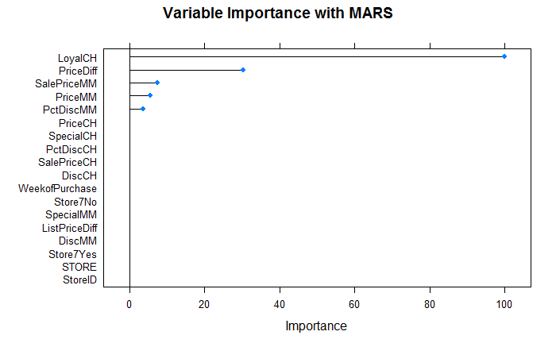

```r
varimp_mars <- varImp(model_mars)

plot(varimp_mars, main = "Variable Importance with MARS")
```

#### 1.5.3.2 Predict on Test Data

```r
predicted <- predict(model_mars, testData4)
head(predicted)
```

```
[1] CH CH CH CH MM CH
Levels: CH MM
```

#### 1.5.3.3 Confusion Matrix

The confusion matrix is a tabular representation to compare the `predictions (data)` vs the `actuals (reference)`. By setting `mode='everything'` pretty much most classification evaluation metrics are computed.

```r
confusionMatrix(reference = testData$Purchase, data = predicted, mode = "everything", positive = "MM")
```

```
Confusion Matrix and Statistics

          Reference
Prediction  CH  MM
        CH 114  26
        MM  16  57

               Accuracy : 0.8028
                 95% CI : (0.743, 0.854)
    No Information Rate : 0.6103
    P-Value [Acc > NIR] : 0.000000001281

                  Kappa : 0.5762

 Mcnemar's Test P-Value : 0.1649

            Sensitivity : 0.6867
            Specificity : 0.8769
         Pos Pred Value : 0.7808
         Neg Pred Value : 0.8143
              Precision : 0.7808
                 Recall : 0.6867
                     F1 : 0.7308
             Prevalence : 0.3897
         Detection Rate : 0.2676
   Detection Prevalence : 0.3427
      Balanced Accuracy : 0.7818

       'Positive' Class : MM
```

```
There were 12 warnings (use warnings() to see them)
```

#### 1.5.3.4 HyperParameter tuning

`tuneLength` `tuneGrid` `trainControl`

Cross validation method can be one amongst:

```
‘boot’: Bootstrap sampling
‘boot632’: Bootstrap sampling with 63.2% bias correction applied
‘optimism_boot’: The optimism bootstrap estimator
‘boot_all’: All boot methods.
‘cv’: k-Fold cross validation
‘repeatedcv’: Repeated k-Fold cross validation
‘oob’: Out of Bag cross validation
‘LOOCV’: Leave one out cross validation
‘LGOCV’: Leave group out cross validation
```

```r
fitControl <- trainControl(method = "cv",    # k-fold cross validation
```

[output not shown]

```r
                           number = 5,       # number of folds
                           savePredictions = "final", # saves predictions for optimal tuning parameter
                           classProbs = T,    # will return class probabilities
                           summaryFunction = twoClassSummary
                           )
```

By settiung the `classProbs=T` the probability scores are generated instead of directly predicting the class based on a predetermined cutoff of 0.5.

The `summaryFunction` can be `twoClassSummary` if Y is binary class or `multiClassSummary` if the Y has more than 2 categories.

##### 1.5.3.4.1 Hyper Parameter Tuning using `tuneLength`

```r
set.seed(100)
```

```
There were 12 warnings (use warnings() to see them)
```

```r
model_mars2 = train(Purchase ~ .,
                    data = trainData,
                    method = "earth",
                    tuneLength = 5,
                    metric="ROC",
                    trControl = fitControl)

model_mars2
```

```
Multivariate Adaptive Regression Spline

857 samples
 18 predictor
  2 classes: 'CH', 'MM'

No pre-processing
Resampling: Cross-Validated (5 fold)
Summary of sample sizes: 685, 686, 685, 686, 686
Resampling results across tuning parameters:

  nprune  ROC        Sens       Spec
   2      0.8837092  0.8757143  0.7094075
   5      0.9025000  0.8795421  0.7513795
   9      0.8929800  0.8719048  0.7423338
  13      0.8930665  0.8719048  0.7393035
  17      0.8930665  0.8719048  0.7393035

Tuning parameter 'degree' was held constant at a value of 1
ROC was used to select the optimal model using the largest value.
The final values used for the model were nprune = 5 and degree = 1.
```

###### 1.5.3.4.1.1 Predict on testData & compute Confusion Matrix

```r
predicted2 <- predict(model_mars2, testData4)
confusionMatrix(reference = testData$Purchase, data = predicted2, mode = "everything", positive="MM")
```

```
Confusion Matrix and Statistics

          Reference
Prediction  CH  MM
        CH 113  27
        MM  17  56

               Accuracy : 0.7934
                 95% CI : (0.7328, 0.8457)
    No Information Rate : 0.6103
    P-Value [Acc > NIR] : 0.000000008319

                  Kappa : 0.556

 Mcnemar's Test P-Value : 0.1748

            Sensitivity : 0.6747
            Specificity : 0.8692
         Pos Pred Value : 0.7671
         Neg Pred Value : 0.8071
              Precision : 0.7671
                 Recall : 0.6747
                     F1 : 0.7179
             Prevalence : 0.3897
         Detection Rate : 0.2629
   Detection Prevalence : 0.3427
      Balanced Accuracy : 0.7720

       'Positive' Class : MM
```

##### 1.5.3.4.2 Hyper Parameter Tuning using `tuneGrid`

```r
marsGrid <- expand.grid(nprune = c(2,4,6,8,10),
```

[output not shown]

```r
                        degree = c(1,2,3) )
```

```r
set.seed(100)

model_mars3 <- train(Purchase ~ .,
                     data = trainData,
                     method="earth",
                     metric="ROC",
                     tuneGrid = marsGrid,
                     trControl = fitControl)

model_mars3
```

```
Multivariate Adaptive Regression Spline

857 samples
 18 predictor
  2 classes: 'CH', 'MM'

No pre-processing
Resampling: Cross-Validated (5 fold)
Summary of sample sizes: 685, 686, 685, 686, 686
Resampling results across tuning parameters:

  degree  nprune  ROC        Sens       Spec
  1        2      0.8837092  0.8757143  0.7094075
  1        4      0.9011512  0.8718315  0.7633198
  1        6      0.9022966  0.8795421  0.7424242
  1        8      0.8986413  0.8757143  0.7483492
  1       10      0.8938458  0.8719048  0.7453641
  2        2      0.8212388  0.8663553  0.6260968
  2        4      0.9028221  0.8776374  0.7693351
  2        6      0.9001307  0.8565201  0.7782451
  2        8      0.8942283  0.8546520  0.7812754
  2       10      0.8941091  0.8546337  0.7753053
  3        2      0.8773872  0.8297802  0.7604251
  3        4      0.9034469  0.8776007  0.7753053
  3        6      0.9026720  0.8660806  0.7631389
  3        8      0.8997006  0.8603846  0.7601085
  3       10      0.8983994  0.8584982  0.7780642

ROC was used to select the optimal model using the largest value.
The final values used for the model were nprune = 4 and degree = 3.
```

###### 1.5.3.4.2.1 Predict on testData & compute Confusion Matrix

```r
predicted3 <- predict(model_mars3, testData4)
```

```
There were 12 warnings (use warnings() to see them)
```

```r
confusionMatrix(reference = testData$Purchase,
                data = predicted3,
                mode = "everything",
                positive = "MM")
```

```
Confusion Matrix and Statistics

          Reference
Prediction  CH  MM
        CH 113  27
        MM  17  56

               Accuracy : 0.7934
                 95% CI : (0.7328, 0.8457)
    No Information Rate : 0.6103
    P-Value [Acc > NIR] : 0.000000008319

                  Kappa : 0.556

 Mcnemar's Test P-Value : 0.1748

            Sensitivity : 0.6747
            Specificity : 0.8692
         Pos Pred Value : 0.7671
         Neg Pred Value : 0.8071
              Precision : 0.7671
                 Recall : 0.6747
                     F1 : 0.7179
             Prevalence : 0.3897
         Detection Rate : 0.2629
   Detection Prevalence : 0.3427
      Balanced Accuracy : 0.7720

       'Positive' Class : MM
```

### 1.5.4 Random Forest

```r
set.seed(100)
model_rf <- train(Purchase ~ . ,
                  data = trainData,
                  method = "rf",
                  tuneLength = 5,
                  trControl = fitControl)
```

```
The metric "Accuracy" was not in the result set. ROC will be used instead.
```

```r
model_rf
```

```
Random Forest

857 samples
 18 predictor
  2 classes: 'CH', 'MM'

No pre-processing
Resampling: Cross-Validated (5 fold)
Summary of sample sizes: 685, 686, 685, 686, 686
Resampling results across tuning parameters:

  mtry  ROC        Sens       Spec
   2    0.8711563  0.8660989  0.6615106
   6    0.8871323  0.8565751  0.7333333
  10    0.8867648  0.8527656  0.7573496
  14    0.8862704  0.8565751  0.7602895
  18    0.8850728  0.8508608  0.7723202

ROC was used to select the optimal model using the largest value.
The final value used for the model was mtry = 6.
```

### 1.5.5 AdaBoost

```r
model_adaboost
```

```
AdaBoost Classification Trees

857 samples
 18 predictor
  2 classes: 'CH', 'MM'

No pre-processing
Resampling: Cross-Validated (5 fold)
Summary of sample sizes: 685, 686, 686, 685, 686
Resampling results across tuning parameters:

  nIter  method         ROC        Sens       Spec
   50    Adaboost.M1    0.8761053  0.8241026  0.7663501
   50    Real adaboost  0.7097309  0.8202198  0.7634555
  100    Adaboost.M1    0.8758153  0.8260073  0.7663048
  100    Real adaboost  0.6768017  0.8297985  0.7514699

ROC was used to select the optimal model using the largest value.
The final values used for the model were nIter = 50 and method = Adaboost.M1.
```

### 1.5.6 xgBoost Dart

This was kept on running for around an hour so finally had to quit & comment the code

```r
model_xgbDART <- train(Purchase ~ .,
                       data = trainData,
                       method = "xgbDART",
                       tuneLength = 5,
                       trControl = fitControl,
                       verbose = F)
```

```
The metric "Accuracy" was not in the result set. ROC will be used instead.
```

### 1.5.7 SVM

```r
model_svmRadial <- train(Purchase ~ .,
                         data=trainData,
                         method = "svmRadial",
                         tuneLength=15,
                         trControl = fitControl)
```

```
The metric "Accuracy" was not in the result set. ROC will be used instead.
```

```r
model_svmRadial
```

```
Support Vector Machines with Radial Basis Function Kernel

857 samples
 18 predictor
  2 classes: 'CH', 'MM'

No pre-processing
Resampling: Cross-Validated (5 fold)
Summary of sample sizes: 686, 685, 685, 686, 686
Resampling results across tuning parameters:

  C        ROC        Sens       Spec
     0.25  0.8947538  0.8871978  0.7275441
     0.50  0.8939467  0.8853114  0.7155586
     1.00  0.8943081  0.8776923  0.7245590
     2.00  0.8921777  0.8833883  0.7155133
     4.00  0.8886999  0.8834249  0.7154681
     8.00  0.8809389  0.8891392  0.6944821
    16.00  0.8736567  0.8834249  0.6676165
    32.00  0.8614444  0.8776740  0.6556309
    64.00  0.8488589  0.8680769  0.6436454
   128.00  0.8313339  0.8661722  0.6287200
   256.00  0.8188002  0.8815201  0.6197648
   512.00  0.8059695  0.8814469  0.6106739
  1024.00  0.7994984  0.8680769  0.5868385
  2048.00  0.7902159  0.8853480  0.5541384
  4096.00  0.7845929  0.8910806  0.5152420

Tuning parameter 'sigma' was held constant at a value of 0.0691729
ROC was used to select the optimal model using the largest value.
The final values used for the model were sigma = 0.0691729 and C = 0.25.
```

## 1.6 resamples() to compare all models

```r
models_comparison <- resamples(list(MARS=model_mars3, RF = model_rf, ADABOOST=model_adaboost, SVM=model_svmRadial))
```

```
There were 12 warnings (use warnings() to see them)
```

```r
summary(models_comparison)
```

```
Call:
summary.resamples(object = models_comparison)

Models: MARS, RF, ADABOOST, SVM
Number of resamples: 5

ROC
              Min.   1st Qu.    Median      Mean   3rd Qu.      Max. NA's
MARS     0.8808081 0.8943743 0.9044776 0.9034469 0.9146411 0.9229334    0
RF       0.8691198 0.8697618 0.8932262 0.8871323 0.8997868 0.9037669    0
ADABOOST 0.8473304 0.8693674 0.8727038 0.8761053 0.8872068 0.9039179    0
SVM      0.8717710 0.8884151 0.8990760 0.8947538 0.9070034 0.9075036    0

Sens
              Min.   1st Qu.    Median      Mean   3rd Qu.      Max. NA's
MARS     0.8365385 0.8476190 0.8952381 0.8776007 0.9038462 0.9047619    0
RF       0.8076923 0.8380952 0.8666667 0.8565751 0.8761905 0.8942308    0
ADABOOST 0.7884615 0.8000000 0.8095238 0.8241026 0.8571429 0.8653846    0
SVM      0.8476190 0.8846154 0.8942308 0.8871978 0.9047619 0.9047619    0

Spec
              Min.   1st Qu.    Median      Mean   3rd Qu.      Max. NA's
MARS     0.7272727 0.7761194 0.7761194 0.7753053 0.7910448 0.8059701    0
RF       0.6666667 0.6716418 0.7462687 0.7333333 0.7761194 0.8059701    0
ADABOOST 0.7272727 0.7313433 0.7761194 0.7663501 0.7910448 0.8059701    0
SVM      0.6417910 0.7164179 0.7272727 0.7275441 0.7611940 0.7910448    0
```

### 1.6.1 Plot resamples summary

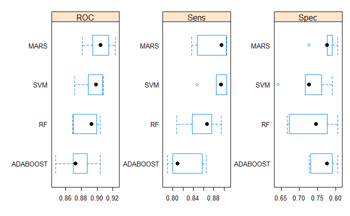

```r
scales <- list( x=list(relation = "free"), y=list(relation = "free") )
bwplot(models_comparison, scales = scales)
```

## 1.7 Ensemble Predictions

this will need another library `caretEnsemble`

```r
# Stacking Algorithms - Run multiple algos in one call.
trainControl <- trainControl(method = "repeatedcv",
                             number = 10,
                             repeats=3,
                             savePredictions = TRUE,
                             classProbs = TRUE)

algorithmList <- c("rf", "adaboost", "earth", "svmRadial")

set.seed(100)
models <- caretList(Purchase ~ ., data=trainData, trControl=trainControl, methodList=algorithmList)
```

```
x$savePredictions == TRUE is depreciated. Setting to 'final' instead.indexes not defined in trControl.  Attempting to set them ourselves, so each model in the ensemble will have the same resampling indexes.
```

```r
results <- resamples(models)
summary(results)
```

```
Call:
summary.resamples(object = results)

Models: rf, adaboost, earth, svmRadial
Number of resamples: 30

Accuracy
               Min.   1st Qu.    Median      Mean   3rd Qu.      Max. NA's
rf        0.7011494 0.7813611 0.8245554 0.8148761 0.8488372 0.8823529    0
adaboost  0.7126437 0.7764706 0.8117647 0.8079169 0.8367305 0.9058824    0
earth     0.7529412 0.8117647 0.8304378 0.8311071 0.8501403 0.9069767    0
svmRadial 0.7647059 0.8000000 0.8245554 0.8268743 0.8567613 0.8953488    0

Kappa
               Min.   1st Qu.    Median      Mean   3rd Qu.      Max. NA's
rf        0.3656758 0.5412023 0.6239376 0.6106210 0.6816051 0.7523310    0
adaboost  0.4059000 0.5332939 0.6054203 0.5973623 0.6539334 0.7973778    0
earth     0.4883921 0.5879658 0.6400500 0.6410969 0.6839406 0.8073908    0
svmRadial 0.4991161 0.5598055 0.6190147 0.6298786 0.6897242 0.7774583    0
```

### 1.7.1 plot ensemble preddictions

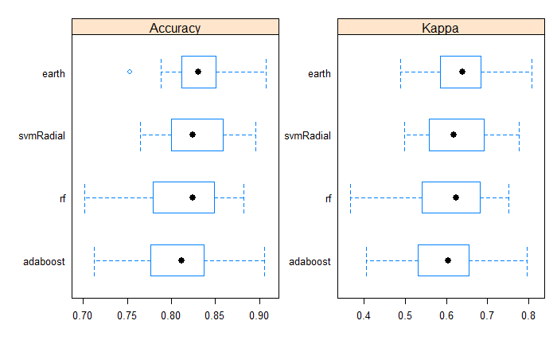

```r
scales <- list( x=list(relation="free"), y=list(relation = "free") )
bwplot(results, scales = scales)
```

## 1.8 Final Prediction -Combine Predictions of multiple models

```r
set.seed(101)
stackControl <- trainControl(method="repeatedcv",
                             number=10,
                             repeats=3,
                             savePredictions=TRUE,
                             classProbs=TRUE)

# Ensemble the predictions of `models` to form a new combined prediction based on glm
stack.glm <- caretStack(models, method="glm", metric="Accuracy", trControl=stackControl)

print(stack.glm)
```

```
A glm ensemble of 4 base models: rf, adaboost, earth, svmRadial

Ensemble results:
Generalized Linear Model

2571 samples
   4 predictor
   2 classes: 'CH', 'MM'

No pre-processing
Resampling: Cross-Validated (10 fold, repeated 3 times)
Summary of sample sizes: 2314, 2314, 2313, 2314, 2315, 2313, ...
Resampling results:

  Accuracy  Kappa
  0.831833  0.6422542
```

### 1.8.1 Predict on testData

```r
stack_predicteds <- predict(stack.glm, newdata = testData4)
head(stack_predicteds)
```

```
[1] CH CH CH CH MM CH
Levels: CH MM
```

### 1.8.2 Confusion Matrix

```r
confusionMatrix(reference = testData$Purchase, data = stack_predicteds, mode = "everything", positive = "MM")
```

```
Confusion Matrix and Statistics

          Reference
Prediction  CH  MM
        CH 114  24
        MM  16  59

               Accuracy : 0.8122
                 95% CI : (0.7532, 0.8623)
    No Information Rate : 0.6103
    P-Value [Acc > NIR] : 0.0000000001758

                  Kappa : 0.5982

 Mcnemar's Test P-Value : 0.2684

            Sensitivity : 0.7108
            Specificity : 0.8769
         Pos Pred Value : 0.7867
         Neg Pred Value : 0.8261
              Precision : 0.7867
                 Recall : 0.7108
                     F1 : 0.7468
             Prevalence : 0.3897
         Detection Rate : 0.2770
   Detection Prevalence : 0.3521
      Balanced Accuracy : 0.7939

       'Positive' Class : MM
```